# HousePricePredictionModel

Rilind Asllani, Aaron Barnes, Brett Jenkins, Nick Russell

12/3/2021

# House Price Prediction Model

In this source code we import, clean, and impute the data, and then we build a linear model to explain and predict future data. Finally, we output the predictions of our model to be evaluate within Kaggle.

## Custom Functions

In order to primarily evaluate the models, we creates custom functions to see the R2, RMSE, and RMSLE of the models. We added a calculation to determine the mode in order to impute data in the cleaning step.

```r
# Define our RMSE and RMSLE functions to evaluate our model
r2 <- function(actual, predicted){
  TSS <- sum((actual - mean(actual))^2)
  RSS <- sum((actual - predicted)^2)
  1 - RSS/TSS
}

rmse <- function(actual, fitted){
  sqrt(mean((actual - fitted)^2))
}

rmsle <- function(actual, fitted) {
  sqrt(mean((log(fitted+1) - log(actual+1))^2))
}

calc_mode <- function(x){
  # List the distinct / unique values
  distinct_values <- na.omit(unique(x))
  # Count the occurrence of each distinct value
  distinct_tabulate <- tabulate(match(x, distinct_values))
  # Return the value with the highest occurrence
  distinct_values[which.max(distinct_tabulate)]
}
```

## Read data into environment

```r
# Read in the data from CSV to RStudio
train_data <- read.csv("train.csv") %>%
  cleaner() %>%
  mutate(SalePrice = log(SalePrice))

# Let's verify that we don't have any missing training data
complete.cases(train_data) %>% all
```

```
## [1] TRUE
```

```r
test_data <- read.csv("test.csv") %>%
  cleaner()

# Let's verify that we don't have any missing test data
complete.cases(test_data) %>% all
```

```
## [1] TRUE
```

```r
# test_data %>%
#    sapply(function(x) sum(is.na(x)))
```

Looks like the data is complete with all ‘NAs’ now imputed.

## Build linear model

The data has been saved to a variable, now we will build out the linear model.

```r
# Create linear model with GLMNET using CARET
set.seed(123)
c_lm <- train(SalePrice ~
                MSSubClass +
                MSZoning +
                LotFrontage +
                LotArea +
                #   Street +
                #   Alley +
                #   LotShape +
                #   LandContour +
                #   Utilities +
                LotConfig +
                LandSlope +
                Neighborhood +
                Condition1 +
                Condition2 +
                BldgType +
                HouseStyle +
                OverallQual * Neighborhood +
                OverallCond * Neighborhood +
                YearBuilt +
                YearRemodAdd +
                RoofStyle +
                RoofMatl +
                Exterior1st +
                Exterior2nd +
                MasVnrType +
                MasVnrArea +
                ExterQual +
                ExterCond +
                Foundation +
                BsmtQual +
                BsmtCond +
                BsmtExposure +
                BsmtFinType1 +
                BsmtFinSF1 +
                BsmtFinType2 +
                BsmtFinSF2 +
                BsmtUnfSF +
                TotalBsmtSF +
                Heating +
                HeatingQC +
                CentralAir +
                Electrical +
                #   X1stFlrSF +  # Highly correlated to 'TotalBsmtSF'
                #   X2ndFlrSF +  # Highly correlated to 'TotalBsmtSF'
                LowQualFinSF +
                GrLivArea +
                BsmtFullBath +
                BsmtHalfBath +
                FullBath +
                HalfBath +
                BedroomAbvGr +
                KitchenAbvGr +
                KitchenQual +
                #   TotRmsAbvGrd +  # Highly correlated to 'GrLivArea'
                Functional +
                Fireplaces +
                FireplaceQu +
                GarageType +
                #   GarageYrBlt +
                GarageFinish +
                GarageCars +
                #   GarageArea +  # Highly correlated to 'GarageCars'
                GarageQual +
                GarageCond +
                PavedDrive +
                WoodDeckSF +
                OpenPorchSF +
                EnclosedPorch +
                X3SsnPorch +
                ScreenPorch +
                #   PoolArea +
                #   PoolQC +
                Fence +
                # MiscFeature +
                MiscVal +
                MoSold +
                YrSold +
                SaleType +
                SaleCondition +
                TotalSF * Neighborhood +
                TotalSF * OverallQual +
                TotalSF * OverallCond +
                Total_Bathrooms +
                Total_Porch_SF +
                HasPool +
                Has2ndFloor +
                HasGarage +
                HasBsmt +
                HasFireplace,
                data = train_data,
                preProcess = c("center", "scale"),
                method = "glmnet")
```

## Evaluating the linaer model

We will evaluate the model now by looking at the R2, RMSE, and other metrics that will give us an idea of how well it predicts the in-sample, and out-of-sample data.

```r
#In-sample performance
#R^2
r2(exp(train_data$SalePrice), exp(fitted(c_lm)))
```

```
## [1] 0.9488683
```

```r
#RSME
rmse(exp(train_data$SalePrice), exp(fitted(c_lm)))
```

```
## [1] 17957.63
```

```r
#RSMLE
rmsle(exp(train_data$SalePrice), exp(fitted(c_lm)))
```

```
## [1] 0.09296549
```

```r
#Out-of-sample performance
best_alpha <- c_lm$results[c_lm$results$alpha==c_lm$bestTune$alpha, ]
best_alpha_lambda <- best_alpha[best_alpha$lambda==c_lm$bestTune$lambda, ]

#R^2
best_alpha_lambda$Rsquared
```

```
## [1] 0.9096817
```

```r
#RSMLE
best_alpha_lambda$RMSE
```

```
## [1] 0.1197894
```

```r
#90% Ridge Regression and 10# Lasso Regression Coefficients Removed
c_lm_coeffs <- coef(c_lm$finalModel, c_lm$bestTune$lambda)
c_lm_Rmvd_Coef <- c_lm_coeffs[c_lm_coeffs[,1]==0,0]
# c_lm_Rmvd_Coef
nrow(c_lm_Rmvd_Coef)
```

```
## [1] 551
```

```r
c_lm_Kept_Coef <- c_lm_coeffs[c_lm_coeffs[,1]!=0,0]
# c_lm_Kept_Coef
nrow(c_lm_Kept_Coef)
```

```
## [1] 191
```

```r
c_lm$bestTune
```

```
##   alpha      lambda
## 5  0.55 0.005918367
```

Both our in-sample and out out-of-sample r-squared metrics look really strong as they are both at or above a 90% explanation of the data.

## Random Forest

We will also use a Random Forest model to compare how well our linear model works. If the random forest is better, we will proceed with using the Random Forest for predictions.

```r
set.seed(123)
c_rf <- train(SalePrice ~ .,
              data = train_data,
              method = "rf",
              preProcess = c("center", "scale"),
              importance = TRUE,
              trControl = trainControl(method = "cv", number = 3))

print(c_rf)
```

```
## Random Forest
##
## 1460 samples
##   89 predictor
##
## Pre-processing: centered (321), scaled (321)
## Resampling: Cross-Validated (3 fold)
## Summary of sample sizes: 973, 974, 973
## Resampling results across tuning parameters:
##
##   mtry  RMSE       Rsquared   MAE
##     2   0.2298735  0.8121337  0.16149357
##   161   0.1453366  0.8713089  0.09657516
##   321   0.1470012  0.8674557  0.09836577
##
## RMSE was used to select the optimal model using the smallest value.
## The final value used for the model was mtry = 161.
```

It doesn’t perform as well as our linear model, so we will proceed with using the linear model for predicting outcomes.

## Visualize the data

In order to help us understand how the data is interacting with itself, we will run some visualizations between features.

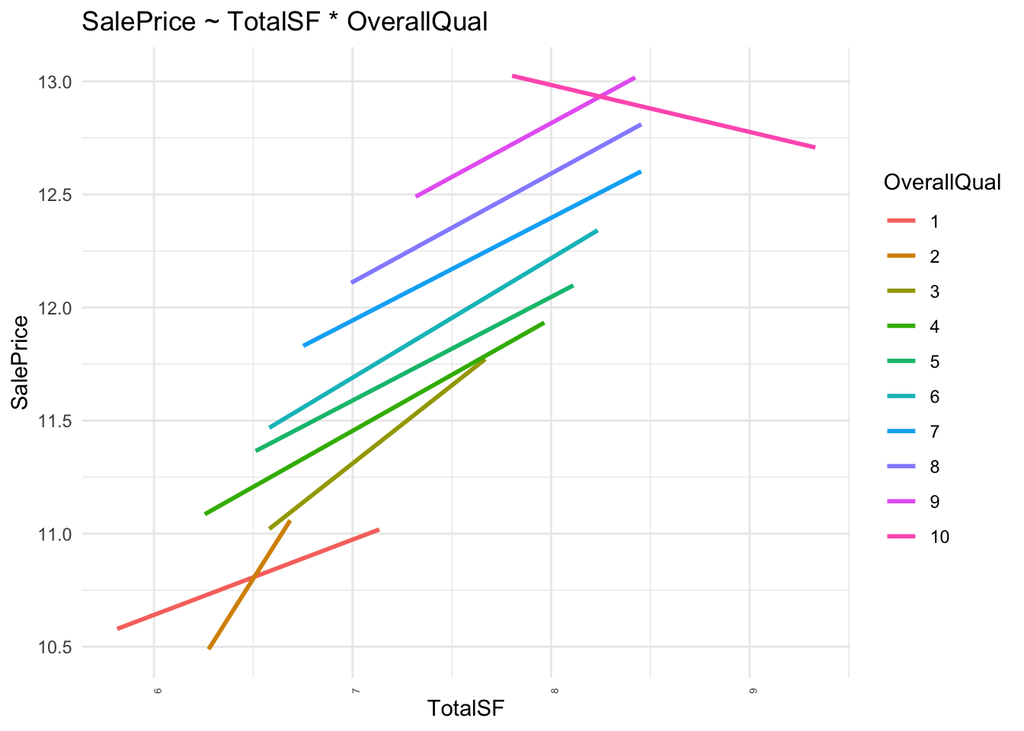

```r
#Evaluating Interactions
ggplot(train_data, aes(TotalSF, SalePrice))+
  theme_minimal() +
  geom_smooth(method = "lm", se = F, aes(col = OverallQual)) +
  theme(axis.text.x = element_text(angle = 90, hjust = 1, size = 5)) +
  labs(title = "SalePrice ~ TotalSF * OverallQual", x = "TotalSF")
```

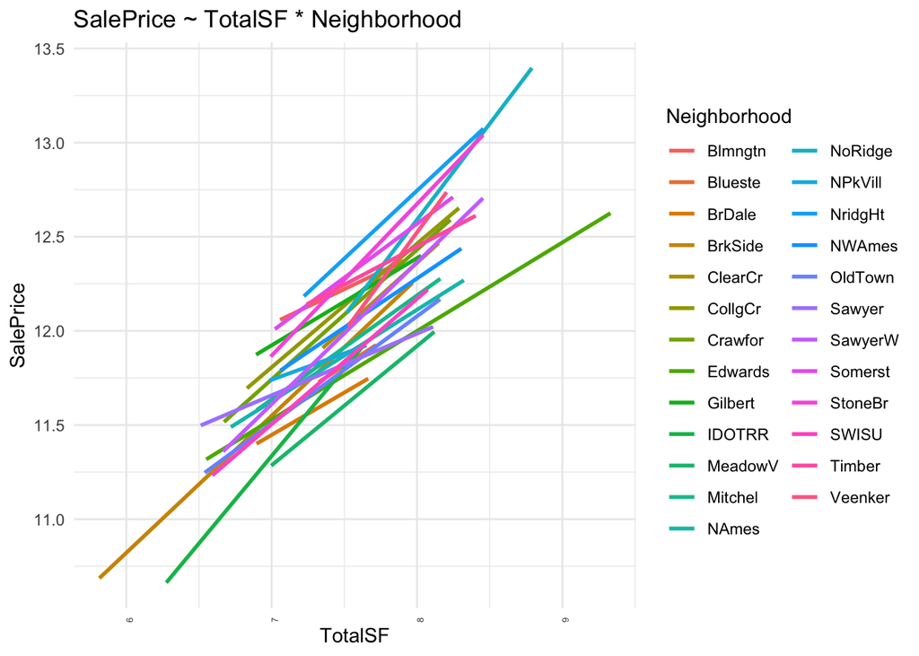

```r
ggplot(train_data, aes(TotalSF, SalePrice))+
  theme_minimal() +
  geom_smooth(method = "lm", se = F, aes(col = Neighborhood)) +
  theme(axis.text.x = element_text(angle = 90, hjust = 1, size = 5)) +
  labs(title = "SalePrice ~ TotalSF * Neighborhood", x = "TotalSF")
```

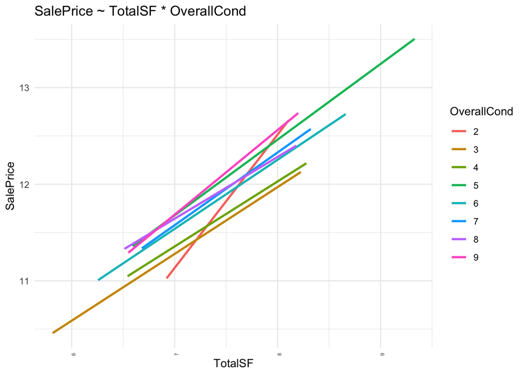

```r
ggplot(train_data, aes(TotalSF, SalePrice))+
  theme_minimal() +
  geom_smooth(method = "lm", se = F, aes(col = OverallCond)) +
  theme(axis.text.x = element_text(angle = 90, hjust = 1, size = 5)) +
  labs(title = "SalePrice ~ TotalSF * OverallCond", x = "TotalSF")
```

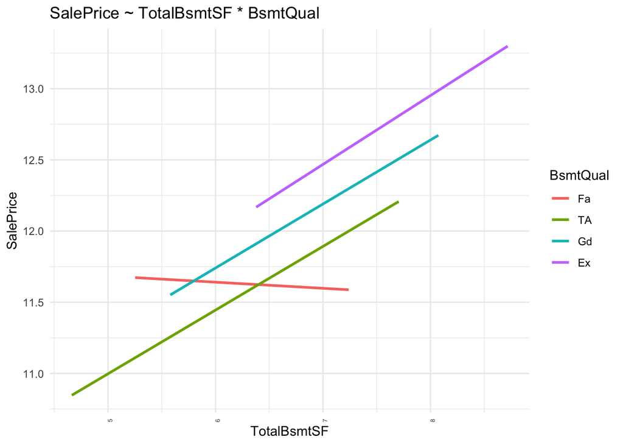

```r
#Experimentation
ggplot(train_data, aes(TotalBsmtSF, SalePrice))+
  theme_minimal() +
  geom_smooth(method = "lm", se = F, aes(col = BsmtQual)) +
  theme(axis.text.x = element_text(angle = 90, hjust = 1, size = 5)) +
  labs(title = "SalePrice ~ TotalBsmtSF * BsmtQual", x = "TotalBsmtSF")
```

[figure not shown]

```r
#Figure Demonstrating Transformation of the Outcome Variable
train_data %>%
  ggplot(aes(exp(TotalSF))) +
  labs(x = "Sale Price (USD)", title = "Distribution of Raw Sale Price") +
  geom_histogram()
```

[figure not shown]

```r
train_data %>%
  ggplot(aes(TotalSF)) +
  labs(x = "Natural Logarithm of Sale Price", title = "Distribution of log Sales Price") +
  geom_histogram()
```

## Creating the submission file

Now that we have a model we can rely on, we will use the model to predict the details on the test data and write those predictions to a file.

```r
submission_data <- test_data %>%
  select(Id) %>%
  mutate(SalePrice = exp(predict(c_lm, test_data)))

write.csv(submission_data, "submission_file.csv", row.names=FALSE)
```

The submission file has been created. Now the output predictions can be loaded into Kaggle for evaluation.